# INCC

O Índice Nacional de Custo da Construção (INCC) é um indicador que apura a evolução dos custos no setor da construção habitacional, um dos termômetros do nível de atividade da economia. Tem como abrangência geográfica sete municípios de capitais: Belo Horizonte, Brasília, Porto Alegre, Recife, Salvador, Rio de Janeiro e São Paulo. O índice nacional resulta da média aritmética ponderada dos sete índices municipais. Apresenta-se em três versões: Índice Nacional de Custo da Construção - 10 (INCC-10), Índice Nacional de Custo da Construção do Mercado (INCC-M) e Índice Nacional de Custo da Construção – Disponibilidade Interna (INCC-DI). A diferença entre eles está no período de apuração das informações para cálculo do índice. Para efeito de coleta de preços, o INCC-DI mede a evolução de preços no período compreendido entre o primeiro ao último dia do mês de referência.

```python
import pandas as pd
import numpy as np
import seaborn as sns
import matplotlib.pyplot as plt
from statsmodels.graphics.tsaplots import plot_acf, plot_pacf #importando autocorrelaçao total e parcial

plt.style.use("ggplot")
```

## Usando a Biblioteca

```python
!pip install ipeadatapy
import ipeadatapy as ip
```

### Específicos

OBS:

- INCC-DI: levantamento de dados feito no primeiro e no último dia do mês em análise;
- INCC-10: levantamento de dados feito no dia 11 do mês anterior e até o dia 10 do mês atual.
- INCC-M: levantamento de dados feito entre o dia 21 do mês anterior até o dia 20 do mês analisado;

Seguiremos então com os seguintes dados do INCC

IGP_INCCG --> INCC-DI: Anual

IGP12_INCC1012 --> INCC-10 - geral - índice (ago. 1994 = 100)

IGP12_INCC12 --> INCC-DI - geral - índice (ago. 1994 = 100)

IGP12_INCCG12 --> INCC-DI: Mensal

IGP12_INCCMG12 --> INCC-M

IGP12_INCCMG1D12 --> INCC-M - 1º decêndio

IGP12_INCCMG2D12 --> INCC-M - 2º decêndio

#### IGP_INCCG

INCC-DI: Anual --> levantamento de dados feito no primeiro e no último dia do mês em análise

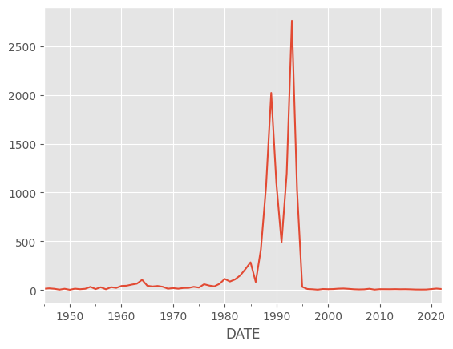

```python
ip.timeseries("IGP_INCCG")
IGP_INCCG = ip.timeseries("IGP_INCCG")

IGP_INCCG["VALUE ((% a.a.))"].plot()
```

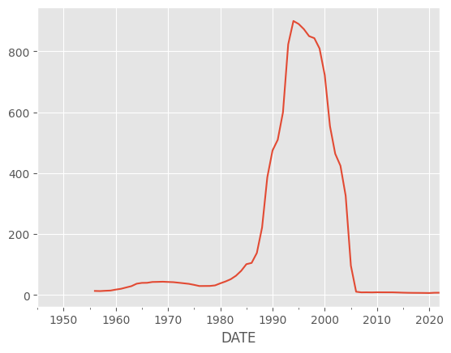

```python
IGP_INCCG["VALUE ((% a.a.))"].rolling(12).mean()
#percebe-se os 12 primeiro nulos, pq so dps do mes 12 conseguimos calcular a média móvel

IGP_INCCG["VALUE ((% a.a.))"].rolling(12).mean().plot()
```

Sazonalidade

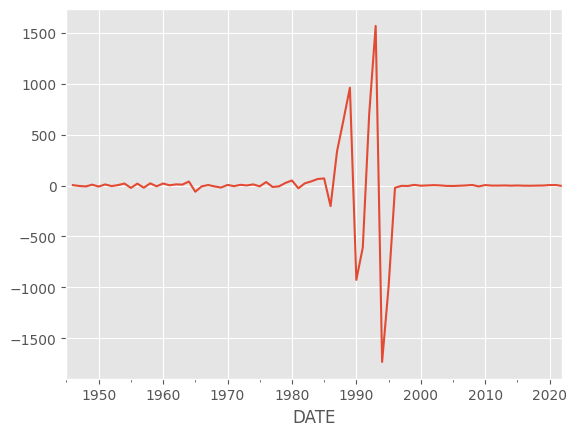

```python
IGP_INCCG["VALUE ((% a.a.))"].diff()

IGP_INCCG["VALUE ((% a.a.))"].diff().plot()
```

Filtrando de 1980 a 2000, para melhor visualização

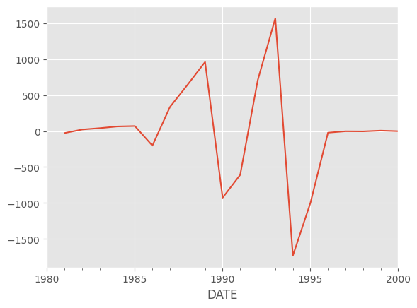

```python
filtro = (IGP_INCCG.index.year >=1980) & (IGP_INCCG.index.year <=2000)
IGP_INCCG[filtro]["VALUE ((% a.a.))"].diff().plot()
```

Parece q a cada 4 anos temos um pico, mas isso ocorre duas vezes so, o que torna a análise um pouco suspeita.

Comportamento Sazonal por mês

- Nesse caso, a base so estava anual, portanto sem analises mensais

```python
#IGP_INCCG["VALUE ((% a.a.))"].diff().groupby(IGP_INCCG.index.month).mean().plot(kind='bar')
```

[output not shown]

Autocorrelação Total e Parcial

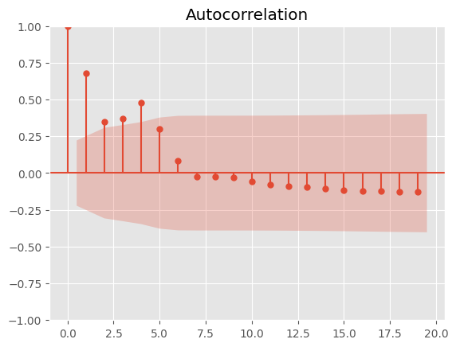

```python
plot_acf(IGP_INCCG["VALUE ((% a.a.))"])
plt.show()
```

Autocorrelação que considera a dependência de todo mundo. Então o lag 2 ta também levando em consideração o lag 1 e o lag 0. Lembrando: lag 0 = 1 porque faz correlaçao entre a variável $X_t$ com ela mesma. Na área de confiança, os valores dentro dos limites em vermelho, consideramos autocorrelação = 0, pois não temos ctz sobre esses valores.

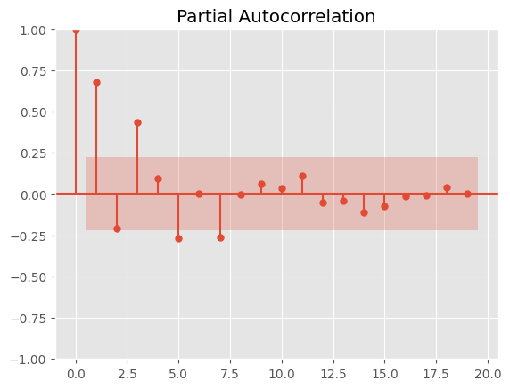

```python
plot_pacf(IGP_INCCG["VALUE ((% a.a.))"])
plt.show()
```

Já nesse gráfico, temos uma autocorrelação independente. Ou seja, vemos direto a influência do $X_t2$ em relação a $X_t$, sem que o $X_t1$ atrapalhe.

Percebe-se que o lag 1 eh significante (acima de 0,5), entao poderiamos usar um modelo autoregressivo com $p = 1$. Logo, AR(1) (https://www.youtube.com/watch?v=OLAfJakUHbs)

#### IGP12_INCC1012

INCC-10 - geral - índice (ago. 1994 = 100) --> levantamento de dados feito no dia 11 do mês anterior e até o dia 10 do mês atual.

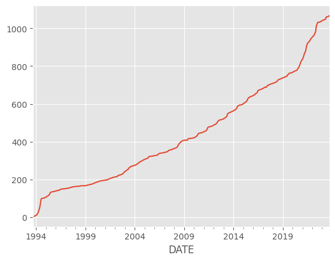

```python
ip.timeseries("IGP12_INCC1012")
IGP12_INCC1012 = ip.timeseries("IGP12_INCC1012")

IGP12_INCC1012.columns

IGP12_INCC1012["VALUE (-)"].plot()
```

Utilizando Média Movel Simples para 12 periodos (12 meses)

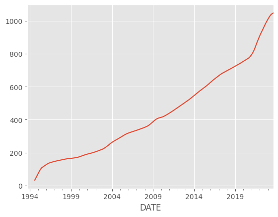

```python
IGP12_INCC1012["VALUE (-)"].rolling(12).mean()
#percebe-se os 12 primeiro nulos, pq so dps do mes 12 conseguimos calcular a média móvel

IGP12_INCC1012["VALUE (-)"].rolling(12).mean().plot()
```

Sazonalidade

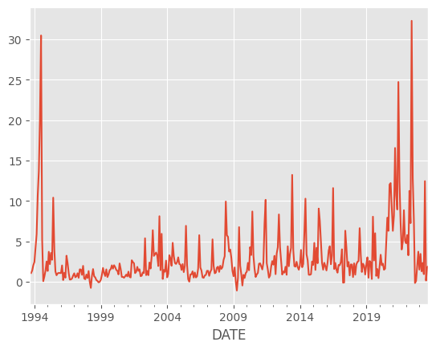

```python
IGP12_INCC1012["VALUE (-)"].diff()

IGP12_INCC1012["VALUE (-)"].diff().plot()
```

Comportamento Sazonal por mês

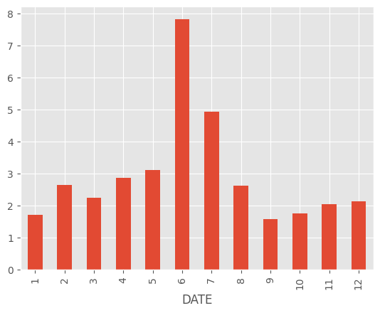

```python
IGP12_INCC1012["VALUE (-)"].diff().groupby(IGP12_INCC1012.index.month).mean().plot(kind='bar')
```

Percebe-se a maior diferença no mês de Junho. Temos então que o maior aumento ocorre nesse mês de cada ano.

Autocorrelação Total e Parcial

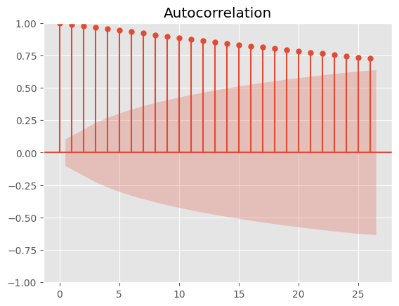

```python
plot_acf(IGP12_INCC1012["VALUE (-)"])
plt.show()
```

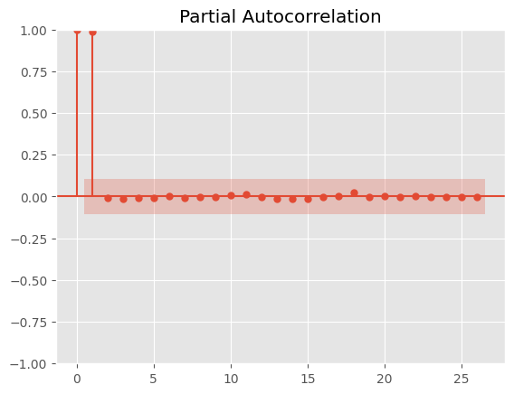

```python
plot_pacf(IGP12_INCC1012["VALUE (-)"])
plt.show()
```

Poderíamos usar um modelo AR(1)

#### IGP12_INCC12

INCC-DI - geral - índice (ago. 1994 = 100) --> levantamento de dados feito no primeiro e no último dia do mês em análise

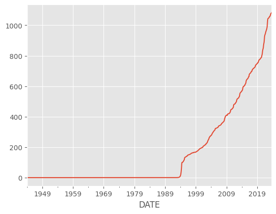

```python
ip.timeseries("IGP12_INCC12")
IGP12_INCC12 = ip.timeseries("IGP12_INCC12")

IGP12_INCC12.columns

IGP12_INCC12["VALUE (-)"].plot()
```

Utilizando Média Movel Simples para 12 periodos (12 meses)

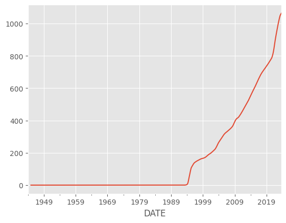

```python
IGP12_INCC12["VALUE (-)"].rolling(12).mean()
#percebe-se os 12 primeiro nulos, pq so dps do mes 12 conseguimos calcular a média móvel

IGP12_INCC12["VALUE (-)"].rolling(12).mean().plot()
```

Sazonalidade

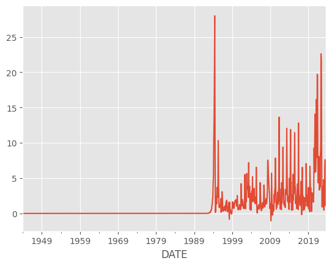

```python
IGP12_INCC12["VALUE (-)"].diff()

IGP12_INCC12["VALUE (-)"].diff().plot()
```

Comportamento Sazonal por mês

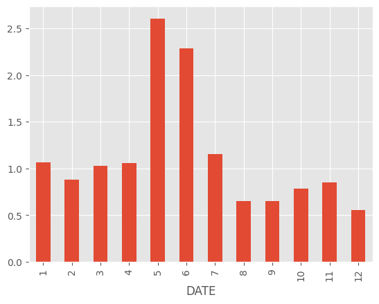

```python
IGP12_INCC12["VALUE (-)"].diff().groupby(IGP12_INCC12.index.month).mean().plot(kind='bar')
```

No gráfico acima, percebemos um crescimento maior entre os meses 4 e 5, revelando a alta no mês de Maio.

Autocorrelação Total e Parcial

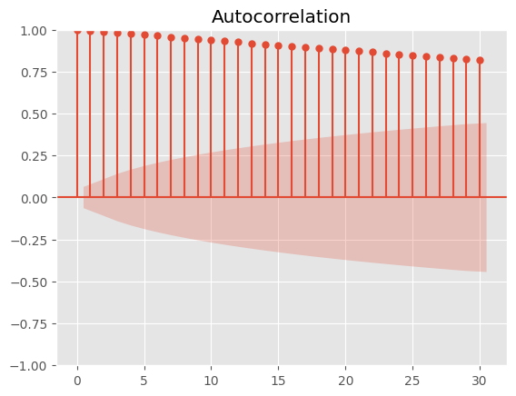

```python
plot_acf(IGP12_INCC12["VALUE (-)"])
plt.show()
```

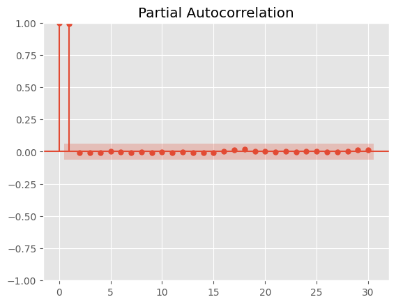

```python
plot_pacf(IGP12_INCC12["VALUE (-)"])
plt.show()
```

Usar modelo AR(1)

#### IGP12_INCCG12

INCC-DI: Mensal --> levantamento de dados feito no primeiro e no último dia do mês em análise

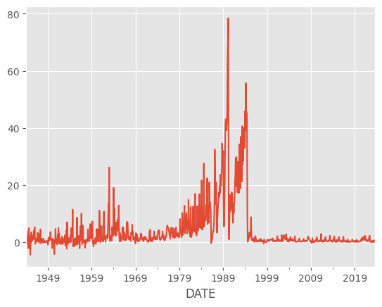

```python
ip.timeseries("IGP12_INCCG12")
IGP12_INCCG12 = ip.timeseries("IGP12_INCCG12")

IGP12_INCCG12.columns

IGP12_INCCG12["VALUE ((% a.m.))"].plot()
```

Utilizando Média Movel Simples para 12 periodos (12 meses)

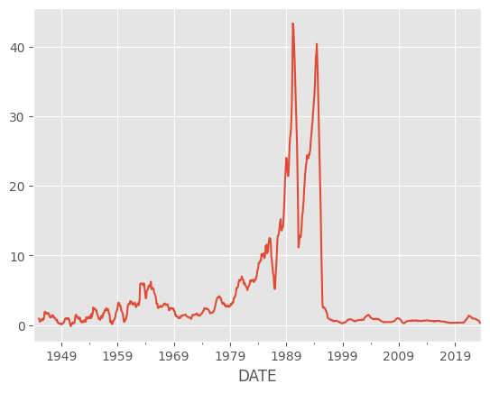

```python
IGP12_INCCG12["VALUE ((% a.m.))"].rolling(12).mean()
#percebe-se os 12 primeiro nulos, pq so dps do mes 12 conseguimos calcular a média móvel

IGP12_INCCG12["VALUE ((% a.m.))"].rolling(12).mean().plot()
```

Sazonalidade

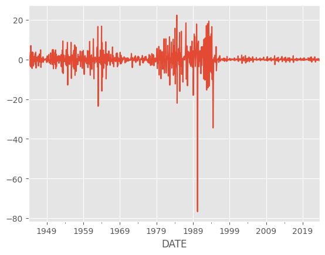

```python
IGP12_INCCG12["VALUE ((% a.m.))"].diff()

IGP12_INCCG12["VALUE ((% a.m.))"].diff().plot()
```

Podemos perceber uma queda brusca no início dos anos 90.

Comportamento Sazonal por mês

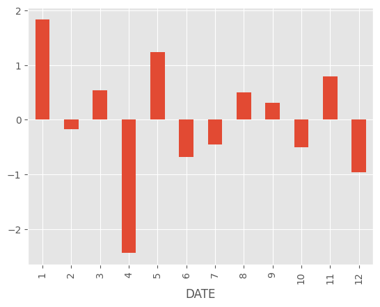

```python
IGP12_INCCG12["VALUE ((% a.m.))"].diff().groupby(IGP12_INCCG12.index.month).mean().plot(kind='bar')
```

Vemos um aumento no início do ano, seguida de uma baixa em Abril.

Autocorrelação Total e Parcial

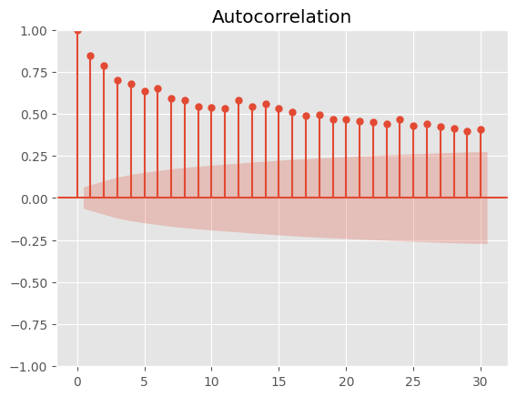

```python
plot_acf(IGP12_INCCG12["VALUE ((% a.m.))"])
plt.show()
```

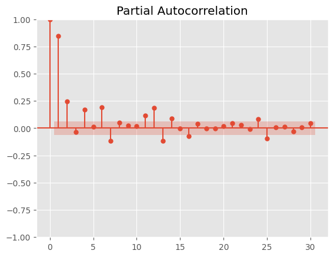

```python
plot_pacf(IGP12_INCCG12["VALUE ((% a.m.))"])
plt.show()
```

Modelo AR(1)

#### IGP12_INCCMG12

INCC-M --> levantamento de dados feito entre o dia 21 do mês anterior até o dia 20 do mês analisado

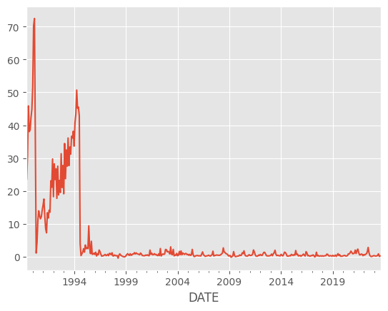

```python
ip.timeseries("IGP12_INCCMG12")
IGP12_INCCMG12 = ip.timeseries("IGP12_INCCMG12")

IGP12_INCCMG12.columns

IGP12_INCCMG12["VALUE ((% a.m.))"].plot()
```

Utilizando Média Movel Simples para 12 periodos (12 meses)

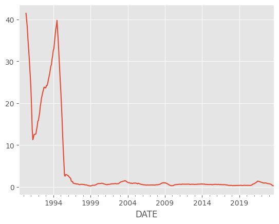

```python
IGP12_INCCMG12["VALUE ((% a.m.))"].rolling(12).mean()
#percebe-se os 12 primeiro nulos, pq so dps do mes 12 conseguimos calcular a média móvel

IGP12_INCCMG12["VALUE ((% a.m.))"].rolling(12).mean().plot()
```

Sazonalidade

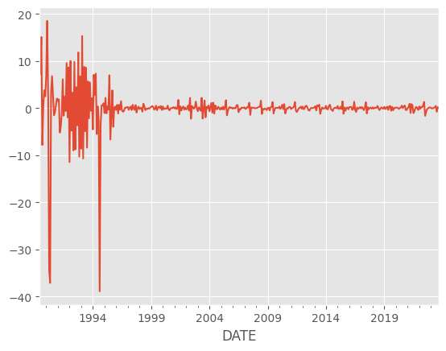

```python
IGP12_INCCMG12["VALUE ((% a.m.))"].diff()

IGP12_INCCMG12["VALUE ((% a.m.))"].diff().plot()
```

Quedas bruscas em 1990 e 1994

Comportamento Sazonal por mês

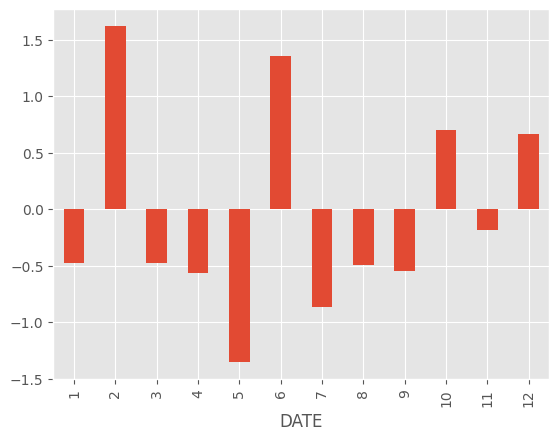

```python
IGP12_INCCMG12["VALUE ((% a.m.))"].diff().groupby(IGP12_INCCMG12.index.month).mean().plot(kind='bar')
```

Aumentos em fevereiro, quedas seguidas de aumento em Maio para Junho

Autocorrelação Total e Parcial

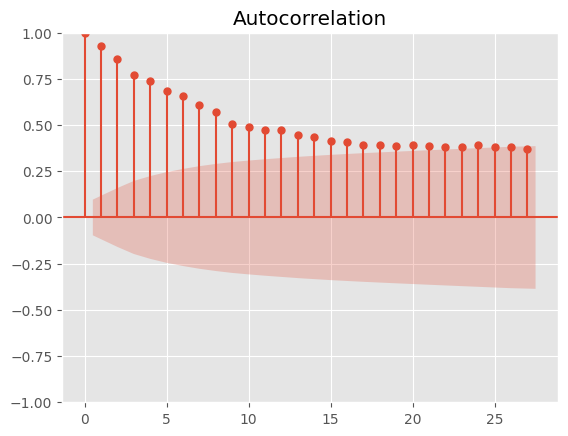

```python
plot_acf(IGP12_INCCMG12["VALUE ((% a.m.))"])
plt.show()
```

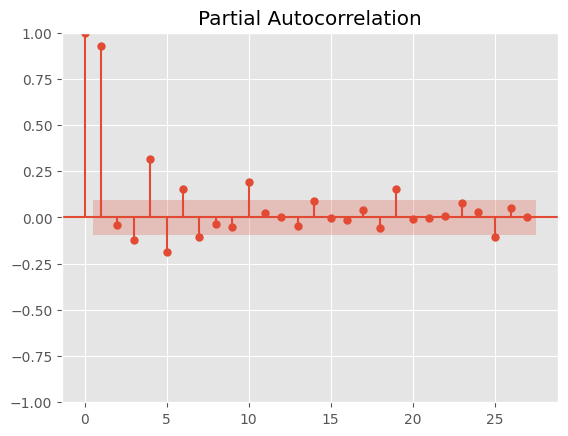

```python
plot_pacf(IGP12_INCCMG12["VALUE ((% a.m.))"])
plt.show()
```

Modelo AR(1)